# Analysing wine based on its chemical composition

Laura Heely, Thouk Koukoulios, Jan Mier, Walker Willard

## The “Business Decision”

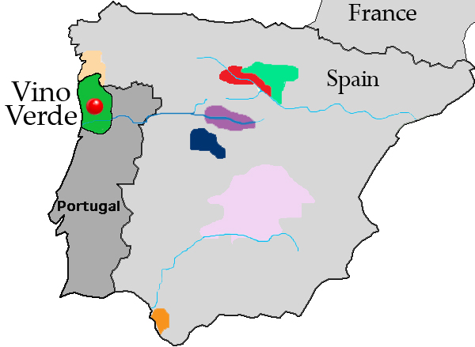

Can we help people screen their white vino verde and save them from drinking some aweful wine? We want to know if we can identfiy aweful wine based on its chemical attributes. As a bonus we will check if we can more generally predict the quality of the wine based on its chemical attributes.

## The Data

For the purpose of this project we identified a multivariate data set from the UCI Machine Learning Repository, which is is a collection of databases, domain theories, and data generators that are used by the machine learning community for the empirical analysis of machine learning algorithms ( *P. Cortez, A. Cerdeira, F. Almeida, T. Matos and J. Reis. Modeling wine preferences by data mining from physicochemical properties. In Decision Support Systems, Elsevier, 47(4):547-553, 2009.*). The data set that we will be using is related to white vino verde wine samples.

We will be using the full data set that has the following 12 attributes:

| Attribute # | Description |
| --- | --- |
| 1 | Fixed acidity |
| 2 | Volatile acidity |
| 3 | Citric acid |
| 4 | Residual sugar |
| 5 | Chlorides |
| 6 | Free sulfur dioxide |
| 7 | Total sulfur dioxide |
| 8 | Density |
| 9 | pH |
| 10 | Sulphates |
| 11 | Alcohol |
| 12 | Quality (score between 0 and 10) |

Let’s have a look at the data for a few wines to get a sense of it. This is how the first 10 out of the total of 4898 wines look:

|  | 01 | 02 | 03 | 04 | 05 | 06 | 07 | 08 | 09 | 10 |
| --- | --- | --- | --- | --- | --- | --- | --- | --- | --- | --- |
| fixed.acidity | 7.00 | 6.30 | 8.10 | 7.20 | 7.20 | 8.10 | 6.20 | 7.00 | 6.30 | 8.10 |
| volatile.acidity | 0.27 | 0.30 | 0.28 | 0.23 | 0.23 | 0.28 | 0.32 | 0.27 | 0.30 | 0.22 |
| citric.acid | 0.36 | 0.34 | 0.40 | 0.32 | 0.32 | 0.40 | 0.16 | 0.36 | 0.34 | 0.43 |
| residual.sugar | 20.70 | 1.60 | 6.90 | 8.50 | 8.50 | 6.90 | 7.00 | 20.70 | 1.60 | 1.50 |
| chlorides | 0.04 | 0.05 | 0.05 | 0.06 | 0.06 | 0.05 | 0.04 | 0.04 | 0.05 | 0.04 |
| free.sulfur.dioxide | 45.00 | 14.00 | 30.00 | 47.00 | 47.00 | 30.00 | 30.00 | 45.00 | 14.00 | 28.00 |
| total.sulfur.dioxide | 170.00 | 132.00 | 97.00 | 186.00 | 186.00 | 97.00 | 136.00 | 170.00 | 132.00 | 129.00 |
| density | 1.00 | 0.99 | 1.00 | 1.00 | 1.00 | 1.00 | 0.99 | 1.00 | 0.99 | 0.99 |
| pH | 3.00 | 3.30 | 3.26 | 3.19 | 3.19 | 3.26 | 3.18 | 3.00 | 3.30 | 3.22 |
| sulphates | 0.45 | 0.49 | 0.44 | 0.40 | 0.40 | 0.44 | 0.47 | 0.45 | 0.49 | 0.45 |
| alcohol | 8.80 | 9.50 | 10.10 | 9.90 | 9.90 | 10.10 | 9.60 | 8.80 | 9.50 | 11.00 |
| quality | 6.00 | 6.00 | 6.00 | 6.00 | 6.00 | 6.00 | 6.00 | 6.00 | 6.00 | 6.00 |

All the data is numeric - that’s fantastic! So, just for fun, let’s zoom out really far and have a look at histograms of all the attributes:

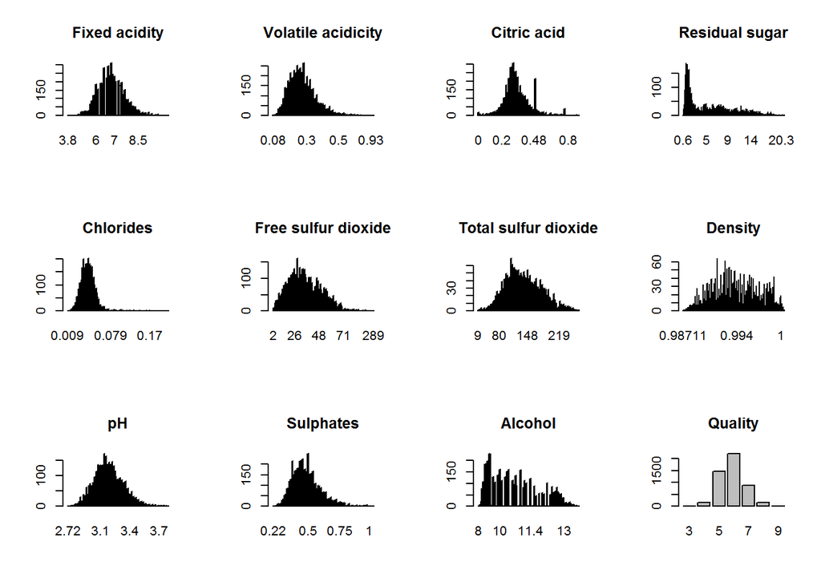

## The analysis process

We chose to design our analysis process based on the 6-step process provided in class. However, instead of using **logistic regression** and **classification and regression trees (CART)** we decided that we would use an implementation of Breiman and Cutler’s **Random Forests for Classification and Regression**. As a result we did not have to restrict ourselves to a binary dependent variable and changed **step 2**.

### Classification in about 6 steps

1. Create an estimation sample and two validation samples by splitting the data into three groups. Steps 2-5 below will then be performed only on the estimation and the first validation data.
2. Set up the dependent variable.
3. Make a preliminary assessment of the relative importance of the explanatory variables using visualization tools and simple descriptive statistics.
4. Estimate the classification model using the estimation data, and interpret the results.
5. Assess the accuracy of classification in the first validation sample, possibly repeating steps 2-5 a few times in different ways to increase performance.
6. Finally, assess the accuracy of classification in the second validation sample. You should eventually use/report all relevant performance measures/plots on this second validation sample only.

So let’s follow these steps.

### Step 1: Split the data

Before performing anything else we must split the dataset into 3 sets: the estimation, validation and test set.

The estimation data and the first validation data are used during steps 2-5 (with a few iterations of these steps), while the second validation data is only used once at the very end before making final business decisions based on the analysis.

We have chosen to do the split ca. 80% estimation, 10% validation, and 10% test data as we had 4898 samples to choose from.

### Step 2: Choose and setup the dependent variable

The main objective of our excercise is to help identify aweful wine based on its chemical attributes. These faulty wines have been defined in our dataset based on their **quality**:

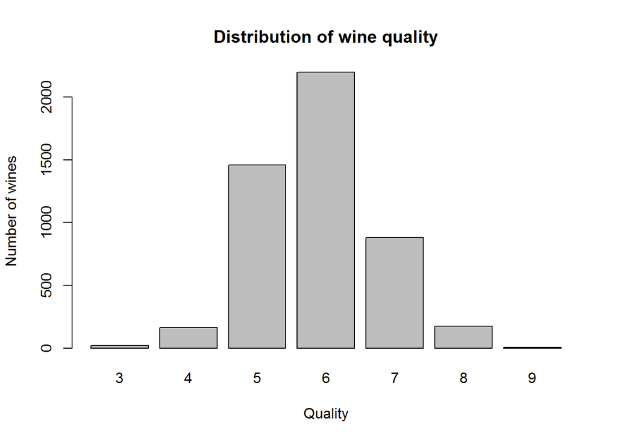

Wines with a quality below 5 are **faulty** - we **do not** want to **drink** these - in fact we do not want to touch them with a ten foot pole.

Interestingly there is a clear distinction between the number of wines classified with quality 5 & 6 and the number of wines classified as over 6. Seeing this we decided to classify wines between **5 and 6** as **average** wines and those with a score **above 6** as **good** wines.

Before we move on, let’s have a quick look at the proportions that of each type of wine in our 3 datasets that we built in step 1. It would be nice if the proportions were similar in all three sets.

| Classification | Quality | # Occurences in estimation data | # Occurences in validation data | # Occurences in test data |
| --- | --- | --- | --- | --- |
| Faulty | 4 or less | 153 (4%) | 18 (4%) | 12 (2%) |
| Average | 5 & 6 | 2913 (74%) | 367 (75%) | 375 (77%) |
| Good | 7 or greater | 852 (22%) | 105 (21%) | 103 (21%) |

### Step 3: Simple Analysis

Lets start the analysis with checking some simple statistical information about the data subsets.

#### Faulty wine

|  | min | 25 percent | median | mean | 75 percent | max | std |
| --- | --- | --- | --- | --- | --- | --- | --- |
| fixed.acidity | 4.20 | 6.40 | 7.00 | 7.20 | 7.90 | 10.30 | 1.14 |
| volatile.acidity | 0.16 | 0.26 | 0.32 | 0.38 | 0.48 | 1.10 | 0.17 |
| citric.acid | 0.00 | 0.22 | 0.29 | 0.31 | 0.42 | 0.88 | 0.16 |
| residual.sugar | 0.70 | 1.40 | 2.90 | 4.99 | 8.20 | 17.55 | 4.49 |
| chlorides | 0.01 | 0.04 | 0.05 | 0.05 | 0.05 | 0.29 | 0.03 |
| free.sulfur.dioxide | 3.00 | 9.00 | 19.00 | 27.23 | 34.00 | 289.00 | 32.04 |
| total.sulfur.dioxide | 19.00 | 86.00 | 119.00 | 132.29 | 178.00 | 440.00 | 63.21 |
| density | 0.99 | 0.99 | 0.99 | 0.99 | 1.00 | 1.00 | 0.00 |
| pH | 2.83 | 3.06 | 3.16 | 3.19 | 3.28 | 3.72 | 0.17 |
| sulphates | 0.25 | 0.38 | 0.47 | 0.48 | 0.54 | 0.87 | 0.12 |
| alcohol | 8.00 | 9.40 | 10.10 | 10.18 | 10.90 | 12.90 | 1.03 |
| quality | 3.00 | 4.00 | 4.00 | 3.88 | 4.00 | 4.00 | 0.32 |

#### Normal wine

|  | min | 25 percent | median | mean | 75 percent | max | std |
| --- | --- | --- | --- | --- | --- | --- | --- |
| fixed.acidity | 3.80 | 6.30 | 6.80 | 6.86 | 7.40 | 14.20 | 0.83 |
| volatile.acidity | 0.08 | 0.21 | 0.26 | 0.28 | 0.32 | 0.96 | 0.09 |
| citric.acid | 0.00 | 0.26 | 0.32 | 0.34 | 0.39 | 1.66 | 0.13 |
| residual.sugar | 0.60 | 1.70 | 6.10 | 6.74 | 10.30 | 65.80 | 5.27 |
| chlorides | 0.01 | 0.04 | 0.04 | 0.05 | 0.05 | 0.35 | 0.02 |
| free.sulfur.dioxide | 2.00 | 23.00 | 34.00 | 35.92 | 47.00 | 131.00 | 16.83 |
| total.sulfur.dioxide | 18.00 | 111.00 | 141.00 | 142.69 | 173.00 | 344.00 | 42.90 |
| density | 0.99 | 0.99 | 0.99 | 0.99 | 1.00 | 1.04 | 0.00 |
| pH | 2.74 | 3.08 | 3.17 | 3.18 | 3.27 | 3.81 | 0.15 |
| sulphates | 0.26 | 0.41 | 0.47 | 0.49 | 0.54 | 1.06 | 0.11 |
| alcohol | 8.00 | 9.40 | 10.10 | 10.28 | 11.00 | 14.00 | 1.11 |
| quality | 5.00 | 5.00 | 6.00 | 5.60 | 6.00 | 6.00 | 0.49 |

#### Good wine

|  | min | 25 percent | median | mean | 75 percent | max | std |
| --- | --- | --- | --- | --- | --- | --- | --- |
| fixed.acidity | 3.90 | 6.20 | 6.70 | 6.72 | 7.20 | 9.20 | 0.77 |
| volatile.acidity | 0.08 | 0.19 | 0.25 | 0.27 | 0.32 | 0.76 | 0.09 |
| citric.acid | 0.01 | 0.28 | 0.31 | 0.33 | 0.36 | 0.74 | 0.08 |
| residual.sugar | 0.90 | 1.70 | 3.80 | 5.20 | 7.40 | 19.25 | 4.27 |
| chlorides | 0.01 | 0.03 | 0.04 | 0.04 | 0.04 | 0.14 | 0.01 |
| free.sulfur.dioxide | 5.00 | 25.00 | 33.00 | 34.14 | 41.62 | 108.00 | 13.44 |
| total.sulfur.dioxide | 34.00 | 100.00 | 121.00 | 124.31 | 144.00 | 229.00 | 32.89 |
| density | 0.99 | 0.99 | 0.99 | 0.99 | 0.99 | 1.00 | 0.00 |
| pH | 2.84 | 3.10 | 3.21 | 3.22 | 3.32 | 3.82 | 0.16 |
| sulphates | 0.22 | 0.40 | 0.48 | 0.50 | 0.58 | 1.08 | 0.13 |
| alcohol | 8.50 | 10.70 | 11.50 | 11.43 | 12.40 | 14.05 | 1.25 |
| quality | 7.00 | 7.00 | 7.00 | 7.18 | 7.00 | 9.00 | 0.40 |

Now let’s do some simple box plots based on the above data as they may help us assess the discriminatory power of the independent variables.

#### Faulty wine

[figure not shown]

#### Normal wine

[figure not shown]

#### Good wine

[figure not shown]

### Step 4: Classification and Interpretation

It is time now to run a classification algorithm on the data set. We have chosen to use the random forest tree algorithm for this.

There are a few basic parameters that can be tuned in order to improve the performance of our model. In particular, since random forests are particulary sensitive to imbalanced datasets (like ours) we will be playing around with **classwt**, **sampsize**, **cutoff**, **mtry**, **ntree**. We will be looking at measures of classification performance to tune these parameters in **step 5**.

For the final version of the model we used the following parameters (for vectors the ordering is average, faulty, good) :

| Parameter | Value |
| --- | --- |
| classwt | 10^{-5}, 1, 1 |
| sampsize | 153, 153, 153 |
| cutoff | 0.35, 0.2, 0.45 |
| mtry | 3 |
| ntree | 200 |

### Step 5: Validation accuracy

Ok, so let’s look at some measures that will help us fine tune the model.

#### Confusion matrix

Let’s start by looking at the results - how many did we get right, how many did we get wrong and what are the missclassification errors like?

|  | Predicted average | Predicted faulty | Predicted good | Class error |
| --- | --- | --- | --- | --- |
| Actual average | 1272 | 925 | 716 | 0.56 |
| Actual faulty | 21 | 123 | 9 | 0.20 |
| Actual good | 102 | 90 | 660 | 0.23 |

… or the same but from a percentage in class perspective (rows sum too 100%)

|  | Predicted average | Predicted faulty | Predicted good |
| --- | --- | --- | --- |
| Actual average | 43.67% | 31.75% | 24.58% |
| Actual faulty | 13.73% | 80.39% | 5.88% |
| Actual good | 11.97% | 10.56% | 77.46% |

#### Classification error rates vs the number of trees in the forest (ntree)

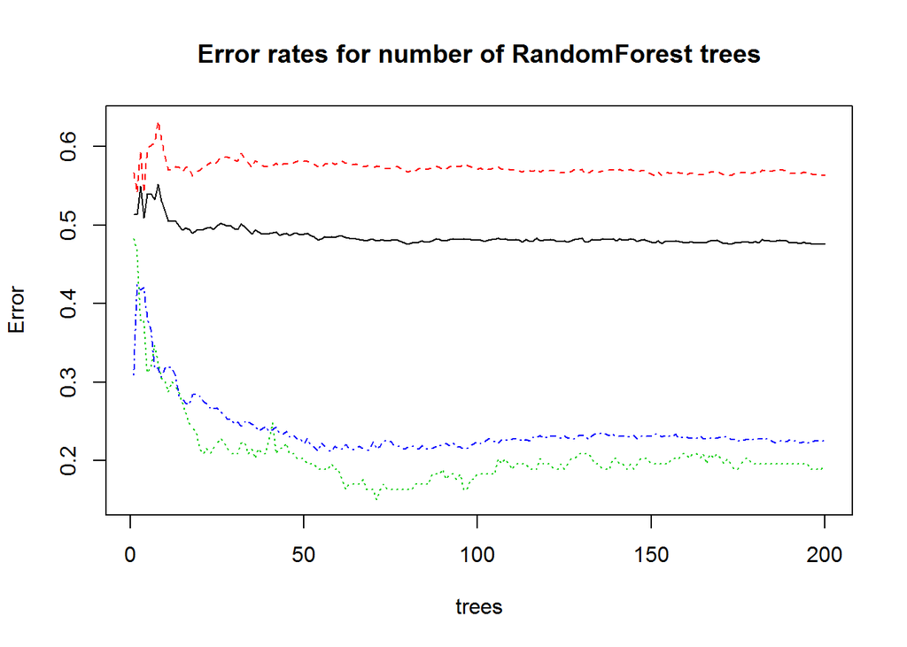

#### ROC curve (for faulty or not faulty)

The ROC curve illustrates the performance of a binary classifier system as its discrimination threshold is varied. The curve shows the true positive rate against the false positive rate at various threshold settings. The true-positive rate is also known as recall and the false-positive rate is also known as the fall-out or probability of false alarm. Since we are more inclined to wrongly categorise **not faulty** wine as **faulty** wine than the other way around we are interested in maximizing the **true-positive rate** (recall).

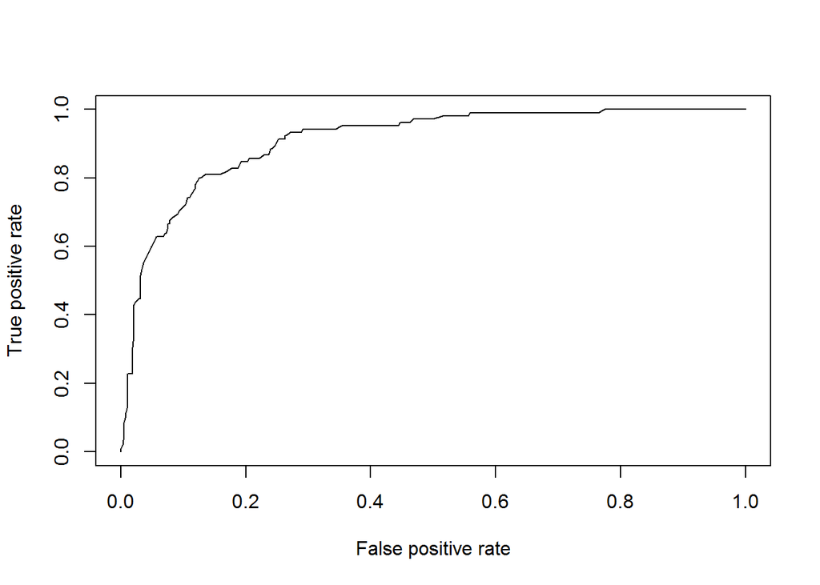

#### Recall-Precision curve (for faulty or not faulty)

Precision ($\frac{true.positives}{true.positives + false.positives}$) and Recall ($\frac{true.positives}{true.positives + false.negatives}$) are inversely related, ie. as Precision increases, recall falls and vice-versa. Since we are more inclined to wrongly categorise **not faulty** wine as **faulty** wine than the other way around we are interested in maximizing Recall.

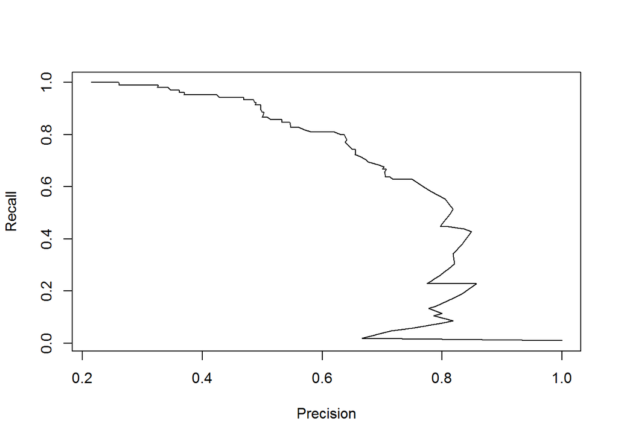

### Step 6: Test accuracy

Let’s finally test the accuracy of the model agains the test dataset that we created at the beginning.

#### Confusion matrix

```
## Confusion Matrix and Statistics
##
##           Reference
## Prediction average faulty good
##    average     159      1   14
##    faulty      124     11    8
##    good         92      0   81
##
## Overall Statistics
##
##                Accuracy : 0.5122
##                  95% CI : (0.467, 0.5573)
##     No Information Rate : 0.7653
##     P-Value [Acc > NIR] : 1
##
##                   Kappa : 0.246
##  Mcnemar's Test P-Value : <2e-16
##
## Statistics by Class:
##
##                      Class: average Class: faulty Class: good
## Sensitivity                  0.4240       0.91667      0.7864
## Specificity                  0.8696       0.72385      0.7623
## Pos Pred Value               0.9138       0.07692      0.4682
## Neg Pred Value               0.3165       0.99712      0.9306
## Prevalence                   0.7653       0.02449      0.2102
## Detection Rate               0.3245       0.02245      0.1653
## Detection Prevalence         0.3551       0.29184      0.3531
## Balanced Accuracy            0.6468       0.82026      0.7743
```

#### ROC curve (for faulty or not faulty)

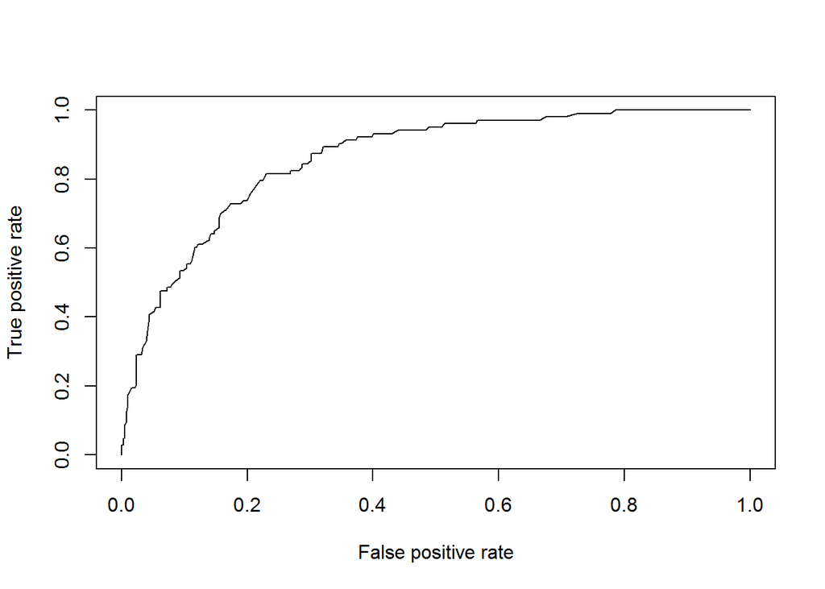

#### Recall-Precision curve (for faulty or not faulty)

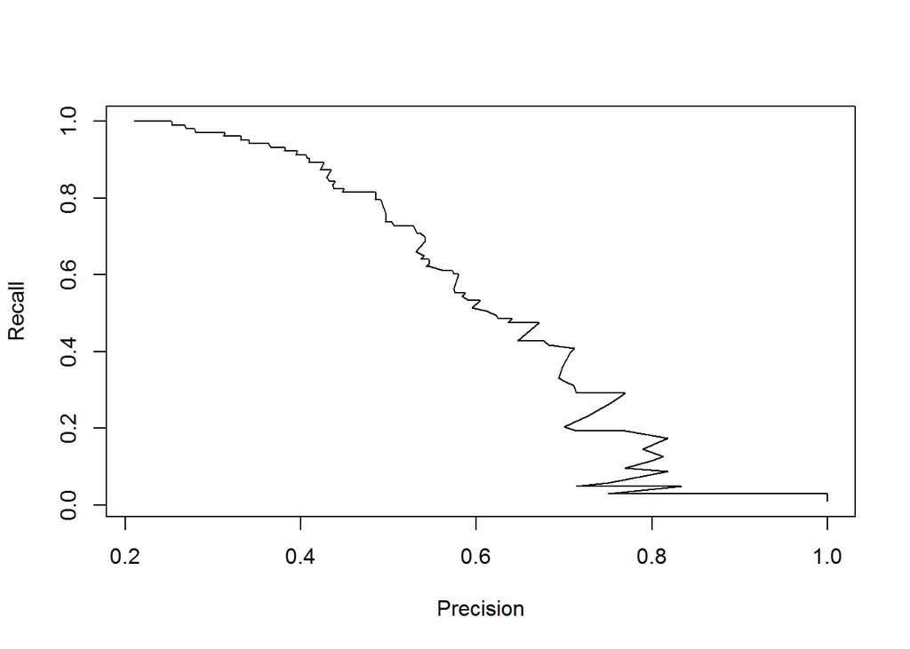

### Conclusions

The model is strongly **biased towards** the **faulty** classification, which is what it was desinged to do. The model is pretty good at predicting the **good** wines. Although the model might seem to be terrible at dealing with the **average** wines (usually splitting them 50% average, 30% faulty, 20% good) we do not care about upward misclassifications. Furthermore, with such an abundance of average wines losing out on 30% of them is not so terrible.

The accuracy of the model will vary depending on the setup of the Estimation and Test data - sometimes it’s good, sometimes it’s not.

Finally, by tweaking the input parameters of the random forest algorithm, we were able to reduce false negatives on faulty wines from about 80-90% down to about 10-20%.

Or more intuitively, if you **randomly picked 1000** vino verde white wines you could expect to get **24 faulty** wines, if you pre-selected based on a **basic random forest model** you could expect to get **20 faulty** wines, and if you pre-selected based on the **tuned random forest** model you could expect to get **2 faulty** wines.

#### And just for fun

Let’s also have a look at the importance (usefulness) of each of variables by using the Mean Decrease in Accuracy (mean decrease in accuracy without the variable) and the Mean Decrease in GINI (mean decrease in node impurity without the variable). Since our focus is on prediction, **we are more interested in the Mean Decrease in Accuracy chart**.

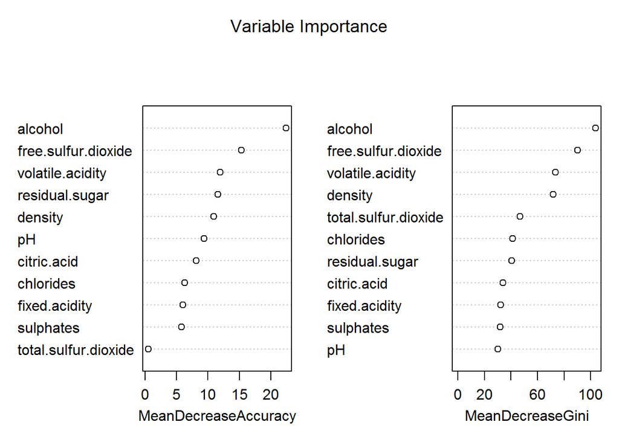